# Module 6 - Team Project: Final Report

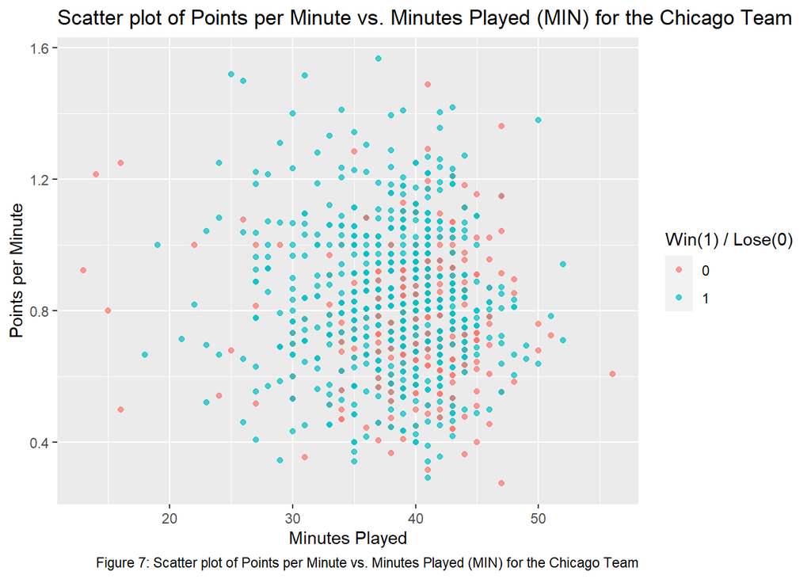

```r
theGraph <- Michael_df %>%
  filter(tm == 'CHI') %>%
  ggplot(aes(x = mp,
             y = pts_per_minute,
             color = as.factor(win))) +
  geom_point(alpha = 0.7) +
  labs(title = "Scatter plot of Points per Minute vs. Minutes Played (MIN) for the Chicago Team",
       x = "Minutes Played",
       y = "Points per Minute",
       caption = "Figure 7: Scatter plot of Points per Minute vs. Minutes Played (MIN) for the Chicago Team",
       color = 'Win(1) / Lose(0)')

theGraph
```

This scatter plot (Figure 7) illustrates the relationship between points per minute and minutes played (MP) during Michael Jordan’s time with the Chicago team. It suggests that when he played more than 50 minutes, the points per minute were possibly lower compared to when he played around 35-45 minutes.

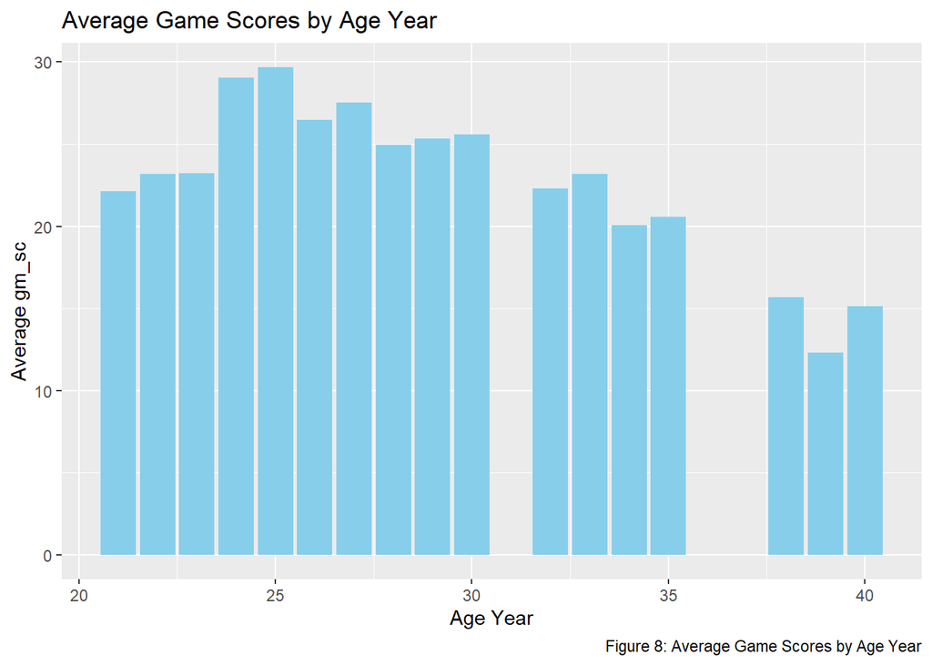

```r
# Create a bar plot of average gm_sc by end_year
theGraph <- Michael_df %>%
  group_by(years) %>%
  summarise(average_gm_sc = mean(gm_sc, na.rm = TRUE)) %>%
  ggplot(aes(x = years, y = average_gm_sc)) +
  geom_bar(stat = "identity", fill = "skyblue") +
  labs(title = "Average Game Scores by Age Year",
       x = "Age Year",
       y = "Average gm_sc",
       caption = "Figure 8: Average Game Scores by Age Year")

theGraph
```

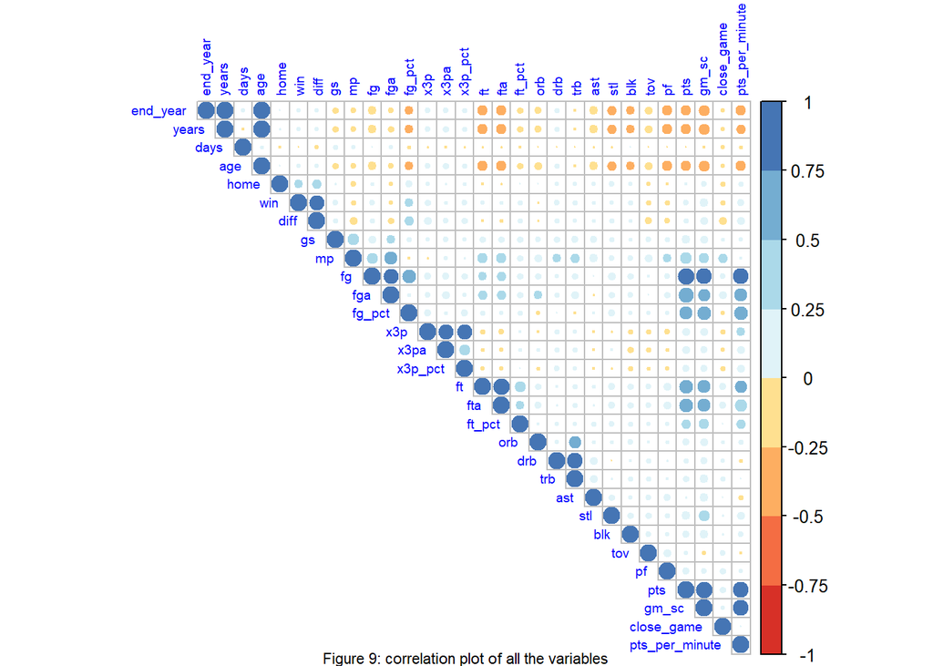

```r
#correlation matrix
numeric_columns <- Michael_df %>%
  select_if(is.numeric) %>%
  select_if(~ !is.factor(.))

cor_matrix <- cor(numeric_columns)

cors <- cor(numeric_columns, use = 'pairwise')
#n=8    => 8 colors
#tl.cex => label size
#tl.col => label color
cor_df <- corrplot(cors, type ='upper',
                   col = brewer.pal(n=8, name='RdYlBu'),
                   tl.col = "blue",
                   tl.cex = 0.6)

# Add a caption using mtext
mtext("Figure 9: correlation plot of all the variables", side = 1, line = 4.2, cex = 0.7)
```

From the correlation matrix (Figure 9), game scores show a strong positive correlation with field goals (FG) and points (PTS), while exhibiting a moderate negative correlation with age.

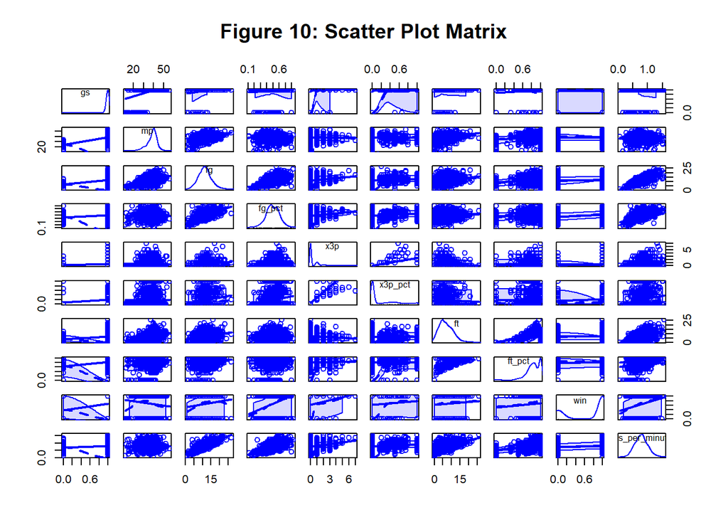

```r
#Scatter plot matrix
scatterplotMatrix(~ gs + mp + fg + fg_pct + x3p + x3p_pct + ft + ft_pct + win + pts_per_minute,
                  data = Michael_df,
                  spread = FALSE,
                  smoother.args = list(lty = 5),
                  main = "Figure 10: Scatter Plot Matrix")
```

From the Scatter Plot Matrix (Figure 10), points per minute show a strong positive relationship with field goals and free throws. Furthermore, the scatter plot for points per minute and 3-pointers forms a bell curve, indicating a peak point in the middle. After that point, points per minute increase, while 3-pointers decrease.

### BQ 1: Test whether the mean points per minute are equal between close games and non-close games

**Based on:** Michael Jordan’s statistics played with Chicago Bulls.

**Using:** t-test.

#### State the hypotheses

-Null Hypothesis (H0): The mean points per minute in close games are equal to the mean points per minute in non-close games.

μ close = μ non-close

```r
Michael_CHI_df <- Michael_df %>%
  filter(tm == 'CHI')

Michael_CHI_df$tm   <- as.factor(Michael_CHI_df$tm)
Michael_CHI_df$opp  <- as.factor(Michael_CHI_df$opp)

#Remove irrelevant variables and duplicate variables
selected_columns1 <- c('end_year', 'tm', 'age', 'days', 'gm_sc', 'diff', 'name')
Michael_CHI_df <- Michael_CHI_df[, !names(Michael_CHI_df) %in% selected_columns1]
```

```r
# Set the significance level
alpha <- 0.05

#Additional Variables
Michael_df <- Michael_df %>%
  mutate(close_game = ifelse(abs(diff) <= 5, 1, 0)) %>%
  mutate(pts_per_minute = pts / mp)


# t-test
#alternative follow H1 sign
result <- t.test(pts_per_minute ~ close_game, data = Michael_CHI_df, alternative = "two.sided")

# Print the result
print(result)
```

```
##
##  Welch Two Sample t-test
##
## data:  pts_per_minute by close_game
## t = -0.0073272, df = 576.3, p-value = 0.9942
## alternative hypothesis: true difference in means between group 0 and group 1 is not equal to 0
## 95 percent confidence interval:
##  -0.02934174  0.02912363
## sample estimates:
## mean in group 0 mean in group 1
##       0.8176988       0.8178078
```

#### Make a decision

```r
p.value <- result$p.value
p.value
```

```
## [1] 0.9941564
```

```r
#Compare the p-value to alpha and make the decision
ifelse(p.value > alpha,
       "Fail to reject the null hypothesis",
       "Reject the null hypothesis")
```

```
## [1] "Fail to reject the null hypothesis"
```

This indicates that there is not enough evidence to reject the null hypothesis (H0) and supports the claim that the mean points per minute in close games are equal to the mean points per minute in non-close games.

We want to test whether is there any difference performance of Michael Jordan whether the game is competitive or not.

Our result suggests that Jordan’s scoring efficiency remained consistent regardless of the game scenario, whether facing pressure or in low-intensity situations, which will be valuable for the basketball team manager to decide who will be the best 5 players to face their opponents when the situation is a close game or a non-close game situation.

BQ1 Recommendation:

Another reason is that if a player is sensitive to a close game such as his performance drops when he plays in a close game situation, the team will decide to take him out and substitute with another player who has a higher tolerance for various situations. The high-tolerance player must be like Michael Jordan who can play consistently to earn more points.

Another situation will be when someone is extremely talented in earning more points in a close game. In order to maximize this player’s performance we must put him to play for that period when the points difference between the two teams is less than 5 points.

### BQ 2: Test whether the mean points per minute differ across different opponent teams

**Based on:** Michael Jordan’s statistics played with Chicago Bulls.

**Using:** ANOVA.

#### State the hypotheses

-Null Hypothesis (H0): There is no significant difference in the mean points per minute across different opponent teams.

μ1 = μ2 = μ3 = … = μn

-Alternative Hypothesis (H1): There is a significant difference in the mean points per minute across different opponent teams. At least one μ is different

```r
# Set the significance level
alpha <- 0.05

# t-test
#alternative follow H1 sign
anova <- aov(pts_per_minute ~ opp, data = Michael_CHI_df)
summary(anova)
```

```
##              Df Sum Sq Mean Sq F value Pr(>F)
## opp          29   1.72 0.05924   1.302  0.133
## Residuals   900  40.95 0.04550
```

```r
# Print the result
summary(anova)
```

```
##              Df Sum Sq Mean Sq F value Pr(>F)
## opp          29   1.72 0.05924   1.302  0.133
## Residuals   900  40.95 0.04550
```

#### Make a decision

```r
a.summay <- summary(anova)
p.value <- a.summay[[1]][[1, "Pr(>F)"]]
p.value
```

```
## [1] 0.133058
```

```r
#Compare the F-value to alpha and make the decision
ifelse(p.value > alpha,
       "Fail to reject the null hypothesis",
       "Reject the null hypothesis")
```

```
## [1] "Fail to reject the null hypothesis"
```

This indicates that there is not enough evidence to reject the null hypothesis (H0) and supports the claim that there is no significant difference in the mean points per minute across different opponent teams.

In the realm of football, we’ve observed players who may not excel overall but exhibit exceptional performance when playing against particular teams. We aim to test the hypothesis that these players possess a unique ability or ‘magic’ specifically associated with certain teams. This investigation is not focused on overall player performance but rather on the extraordinary phenomenon of their scoring abilities, which seem to manifest only against specific teams (potentially more than one)

Our result suggests that Jordan’s performance remained consistent regardless of the opposing team, challenging previous notions about matchup dynamics and highlighting his ability to perform consistently against any opponent.

BQ2 Recommendation:

-The basketball manager is seeking a player with consistent performance, akin to Michael Jordan, who consistently earned the same points regardless of the opposing teams.

-The consequence could be that teams might need to focus on overall improvement rather than tailoring strategies based on specific opponents, assuming that the performance doesn’t significantly vary.

### BQ 3: Test whether winning percentage by year is independent on game score levels

**Based on:** Michael Jordan’s statistics played.

**Using:** Chi-square

A team winning percentage is defined as a measure that reflects the proportion of games won relative to the total number of games played.

#### State the hypotheses

H0: Winning percentage by year is independent on game score levels.

H1: Winning percentage by year is dependent on game score levels.

Game score levels can be divided by 3 groups: < 24, 25-40, 41+

```r
skim(Michael_df)
```

Data summary

| Name | Michael_df |
| --- | --- |
| Number of rows | 1072 |
| Number of columns | 33 |
| _______________________ |  |
| Column type frequency: |  |
| character | 3 |
| numeric | 30 |
| ________________________ |  |
| Group variables | None |

**Variable type: character**

| skim_variable | n_missing | complete_rate | min | max | empty | n_unique | whitespace |
| --- | --- | --- | --- | --- | --- | --- | --- |
| tm | 0 | 1 | 3 | 3 | 0 | 2 | 0 |
| opp | 0 | 1 | 3 | 3 | 0 | 33 | 0 |
| name | 0 | 1 | 14 | 14 | 0 | 1 | 0 |

**Variable type: numeric**

| skim_variable | n_missing | complete_rate | mean | sd | p0 | p25 | p50 | p75 | p100 | hist |
| --- | --- | --- | --- | --- | --- | --- | --- | --- | --- | --- |
| end_year | 0 | 1 | 1992.89 | 5.36 | 1985.00 | 1989.00 | 1992.00 | 1997.00 | 2003.00 | ▆▇▂▆▃ |
| years | 0 | 1 | 29.28 | 5.35 | 21.00 | 25.00 | 28.00 | 33.00 | 40.00 | ▆▇▅▅▃ |
| days | 0 | 1 | 201.63 | 137.58 | 0.00 | 42.00 | 274.00 | 320.00 | 365.00 | ▇▁▁▅▇ |
| age | 0 | 1 | 29.83 | 5.36 | 21.69 | 25.73 | 28.86 | 33.92 | 40.16 | ▇▇▃▆▃ |
| home | 0 | 1 | 0.50 | 0.50 | 0.00 | 0.00 | 0.50 | 1.00 | 1.00 | ▇▁▁▁▇ |
| win | 0 | 1 | 0.66 | 0.47 | 0.00 | 0.00 | 1.00 | 1.00 | 1.00 | ▅▁▁▁▇ |
| diff | 0 | 1 | 4.87 | 12.81 | -44.00 | -4.00 | 5.00 | 13.00 | 47.00 | ▁▂▇▅▁ |
| gs | 0 | 1 | 0.97 | 0.17 | 0.00 | 1.00 | 1.00 | 1.00 | 1.00 | ▁▁▁▁▇ |
| mp | 0 | 1 | 38.26 | 5.71 | 12.00 | 36.00 | 39.00 | 42.00 | 56.00 | ▁▁▅▇▁ |
| fg | 0 | 1 | 11.37 | 3.83 | 1.00 | 9.00 | 11.00 | 14.00 | 27.00 | ▂▇▇▂▁ |
| fga | 0 | 1 | 22.89 | 5.94 | 5.00 | 19.00 | 23.00 | 27.00 | 49.00 | ▁▇▇▁▁ |
| fg_pct | 0 | 1 | 0.50 | 0.11 | 0.11 | 0.42 | 0.50 | 0.57 | 0.83 | ▁▂▇▆▁ |
| x3p | 0 | 1 | 0.54 | 0.97 | 0.00 | 0.00 | 0.00 | 1.00 | 7.00 | ▇▁▁▁▁ |
| x3pa | 0 | 1 | 1.66 | 1.75 | 0.00 | 0.00 | 1.00 | 3.00 | 12.00 | ▇▂▁▁▁ |
| x3p_pct | 0 | 1 | 0.19 | 0.31 | 0.00 | 0.00 | 0.00 | 0.33 | 1.00 | ▇▁▁▁▁ |
| ft | 0 | 1 | 6.83 | 4.08 | 0.00 | 4.00 | 6.00 | 10.00 | 26.00 | ▇▇▃▁▁ |
| fta | 0 | 1 | 8.18 | 4.63 | 0.00 | 5.00 | 8.00 | 11.00 | 27.00 | ▆▇▅▁▁ |
| ft_pct | 0 | 1 | 0.81 | 0.21 | 0.00 | 0.75 | 0.83 | 1.00 | 1.00 | ▁▁▁▅▇ |
| orb | 0 | 1 | 1.56 | 1.44 | 0.00 | 0.00 | 1.00 | 2.00 | 8.00 | ▇▅▁▁▁ |
| drb | 0 | 1 | 4.67 | 2.57 | 0.00 | 3.00 | 4.00 | 6.00 | 14.00 | ▃▇▅▂▁ |
| trb | 0 | 1 | 6.22 | 3.02 | 0.00 | 4.00 | 6.00 | 8.00 | 18.00 | ▃▇▃▂▁ |
| ast | 0 | 1 | 5.25 | 2.72 | 0.00 | 3.00 | 5.00 | 7.00 | 17.00 | ▆▇▅▁▁ |
| stl | 0 | 1 | 2.35 | 1.66 | 0.00 | 1.00 | 2.00 | 3.00 | 10.00 | ▇▅▁▁▁ |
| blk | 0 | 1 | 0.83 | 1.01 | 0.00 | 0.00 | 1.00 | 1.00 | 6.00 | ▇▂▁▁▁ |
| tov | 0 | 1 | 2.73 | 1.73 | 0.00 | 1.00 | 3.00 | 4.00 | 9.00 | ▅▇▃▁▁ |
| pf | 0 | 1 | 2.60 | 1.39 | 0.00 | 2.00 | 3.00 | 4.00 | 6.00 | ▇▇▇▅▃ |
| pts | 0 | 1 | 30.12 | 9.75 | 2.00 | 23.00 | 30.00 | 36.00 | 69.00 | ▁▆▇▂▁ |
| gm_sc | 0 | 1 | 23.44 | 9.49 | -1.40 | 16.80 | 23.45 | 29.60 | 64.60 | ▂▇▆▁▁ |
| close_game | 0 | 1 | 0.31 | 0.46 | 0.00 | 0.00 | 0.00 | 1.00 | 1.00 | ▇▁▁▁▃ |
| pts_per_minute | 0 | 1 | 0.79 | 0.23 | 0.05 | 0.63 | 0.78 | 0.93 | 1.57 | ▁▅▇▃▁ |

```r
# Grouping data by end_year and calculating the team winning percentage

team_win_percentage <- Michael_df %>%
  mutate(gm_sc_bin = cut(gm_sc, breaks = c(-Inf, 24, 40, Inf), labels = c("0-24", "25-40", "41+"))) %>%
  group_by(end_year, gm_sc_bin) %>%
  summarise(
    total_games = n(),                      # Total number of games played
    total_wins = sum(win),                  # Total number of games won
    team_winning_percentage = total_wins / total_games  # Winning percentage
  )
# Viewing the resulting dataset with team winning percentage
print(team_win_percentage)
```

```
## # A tibble: 40 × 5
## # Groups:   end_year [15]
##    end_year gm_sc_bin total_games total_wins team_winning_percentage
##       <dbl> <fct>           <int>      <dbl>                   <dbl>
##  1     1985 0-24               49         18                   0.367
##  2     1985 25-40              29         17                   0.586
##  3     1985 41+                 4          3                   0.75
##  4     1986 0-24               16          8                   0.5
##  5     1986 25-40               2          1                   0.5
##  6     1987 0-24               32         10                   0.312
##  7     1987 25-40              42         23                   0.548
##  8     1987 41+                 8          7                   0.875
##  9     1988 0-24               24         10                   0.417
## 10     1988 25-40              51         33                   0.647
## # ℹ 30 more rows
```

```r
# Create vectors for each row
r1 <- c(sum(team_win_percentage$team_winning_percentage[team_win_percentage$end_year == 1985 & team_win_percentage$gm_sc_bin == "0-24"]),
        sum(team_win_percentage$team_winning_percentage[team_win_percentage$end_year == 1985 & team_win_percentage$gm_sc_bin == "25-40"]),
        sum(team_win_percentage$team_winning_percentage[team_win_percentage$end_year == 1985 & team_win_percentage$gm_sc_bin == "41+"]))

r2 <- c(sum(team_win_percentage$team_winning_percentage[team_win_percentage$end_year == 1986 & team_win_percentage$gm_sc_bin == "0-24"]),
        sum(team_win_percentage$team_winning_percentage[team_win_percentage$end_year == 1986 & team_win_percentage$gm_sc_bin == "25-40"]),
        sum(team_win_percentage$team_winning_percentage[team_win_percentage$end_year == 1986 & team_win_percentage$gm_sc_bin == "41+"]))

r3 <- c(sum(team_win_percentage$team_winning_percentage[team_win_percentage$end_year == 1987 & team_win_percentage$gm_sc_bin == "0-24"]),
        sum(team_win_percentage$team_winning_percentage[team_win_percentage$end_year == 1987 & team_win_percentage$gm_sc_bin == "25-40"]),
        sum(team_win_percentage$team_winning_percentage[team_win_percentage$end_year == 1987 & team_win_percentage$gm_sc_bin == "41+"]))

r4 <- c(sum(team_win_percentage$team_winning_percentage[team_win_percentage$end_year == 1988 & team_win_percentage$gm_sc_bin == "0-24"]),
        sum(team_win_percentage$team_winning_percentage[team_win_percentage$end_year == 1988 & team_win_percentage$gm_sc_bin == "25-40"]),
        sum(team_win_percentage$team_winning_percentage[team_win_percentage$end_year == 1988 & team_win_percentage$gm_sc_bin == "41+"]))

r5 <- c(sum(team_win_percentage$team_winning_percentage[team_win_percentage$end_year == 1989 & team_win_percentage$gm_sc_bin == "0-24"]),
        sum(team_win_percentage$team_winning_percentage[team_win_percentage$end_year == 1989 & team_win_percentage$gm_sc_bin == "25-40"]),
        sum(team_win_percentage$team_winning_percentage[team_win_percentage$end_year == 1989 & team_win_percentage$gm_sc_bin == "41+"]))

r6 <- c(sum(team_win_percentage$team_winning_percentage[team_win_percentage$end_year == 1990 & team_win_percentage$gm_sc_bin == "0-24"]),
        sum(team_win_percentage$team_winning_percentage[team_win_percentage$end_year == 1990 & team_win_percentage$gm_sc_bin == "25-40"]),
        sum(team_win_percentage$team_winning_percentage[team_win_percentage$end_year == 1990 & team_win_percentage$gm_sc_bin == "41+"]))

r7 <- c(sum(team_win_percentage$team_winning_percentage[team_win_percentage$end_year == 1991 & team_win_percentage$gm_sc_bin == "0-24"]),
        sum(team_win_percentage$team_winning_percentage[team_win_percentage$end_year == 1991 & team_win_percentage$gm_sc_bin == "25-40"]),
        sum(team_win_percentage$team_winning_percentage[team_win_percentage$end_year == 1991 & team_win_percentage$gm_sc_bin == "41+"]))

r8 <- c(sum(team_win_percentage$team_winning_percentage[team_win_percentage$end_year == 1992 & team_win_percentage$gm_sc_bin == "0-24"]),
        sum(team_win_percentage$team_winning_percentage[team_win_percentage$end_year == 1992 & team_win_percentage$gm_sc_bin == "25-40"]),
        sum(team_win_percentage$team_winning_percentage[team_win_percentage$end_year == 1992 & team_win_percentage$gm_sc_bin == "41+"]))

r9 <- c(sum(team_win_percentage$team_winning_percentage[team_win_percentage$end_year == 1993 & team_win_percentage$gm_sc_bin == "0-24"]),
        sum(team_win_percentage$team_winning_percentage[team_win_percentage$end_year == 1993 & team_win_percentage$gm_sc_bin == "25-40"]),
        sum(team_win_percentage$team_winning_percentage[team_win_percentage$end_year == 1993 & team_win_percentage$gm_sc_bin == "41+"]))

r10 <- c(sum(team_win_percentage$team_winning_percentage[team_win_percentage$end_year == 1995 & team_win_percentage$gm_sc_bin == "0-24"]),
        sum(team_win_percentage$team_winning_percentage[team_win_percentage$end_year == 1995 & team_win_percentage$gm_sc_bin == "25-40"]),
        sum(team_win_percentage$team_winning_percentage[team_win_percentage$end_year == 1995 & team_win_percentage$gm_sc_bin == "41+"]))

r11 <- c(sum(team_win_percentage$team_winning_percentage[team_win_percentage$end_year == 1996 & team_win_percentage$gm_sc_bin == "0-24"]),
        sum(team_win_percentage$team_winning_percentage[team_win_percentage$end_year == 1996 & team_win_percentage$gm_sc_bin == "25-40"]),
        sum(team_win_percentage$team_winning_percentage[team_win_percentage$end_year == 1996 & team_win_percentage$gm_sc_bin == "41+"]))

r12 <- c(sum(team_win_percentage$team_winning_percentage[team_win_percentage$end_year == 1997 & team_win_percentage$gm_sc_bin == "0-24"]),
        sum(team_win_percentage$team_winning_percentage[team_win_percentage$end_year == 1997 & team_win_percentage$gm_sc_bin == "25-40"]),
        sum(team_win_percentage$team_winning_percentage[team_win_percentage$end_year == 1997 & team_win_percentage$gm_sc_bin == "41+"]))

r13 <- c(sum(team_win_percentage$team_winning_percentage[team_win_percentage$end_year == 1998 & team_win_percentage$gm_sc_bin == "0-24"]),
        sum(team_win_percentage$team_winning_percentage[team_win_percentage$end_year == 1998 & team_win_percentage$gm_sc_bin == "25-40"]),
        sum(team_win_percentage$team_winning_percentage[team_win_percentage$end_year == 1998 & team_win_percentage$gm_sc_bin == "41+"]))

r14 <- c(sum(team_win_percentage$team_winning_percentage[team_win_percentage$end_year == 2002 & team_win_percentage$gm_sc_bin == "0-24"]),
        sum(team_win_percentage$team_winning_percentage[team_win_percentage$end_year == 2002 & team_win_percentage$gm_sc_bin == "25-40"]),
        sum(team_win_percentage$team_winning_percentage[team_win_percentage$end_year == 2002 & team_win_percentage$gm_sc_bin == "41+"]))

r15 <- c(sum(team_win_percentage$team_winning_percentage[team_win_percentage$end_year == 2003 & team_win_percentage$gm_sc_bin == "0-24"]),
        sum(team_win_percentage$team_winning_percentage[team_win_percentage$end_year == 2003 & team_win_percentage$gm_sc_bin == "25-40"]),
        sum(team_win_percentage$team_winning_percentage[team_win_percentage$end_year == 2003 & team_win_percentage$gm_sc_bin == "41+"]))

# State the number of rows for the matrix
 rows <- 15

# Create a matrix from rows
mtrx <- matrix(c(r1, r2, r3, r4, r5,r6,r7,r8 ,r9 ,r10 ,r11 ,r12 ,r13, r14, r15), nrow = rows, byrow = TRUE)

# Name the rows and columns
rownames(mtrx) <- c("1985", "1986", "1987", "1988", "1989", "1990", "1991", "1992", "1993", "1995", "1996", "1997", "1998", "2002", "2003")
colnames(mtrx) <- c("0-20", "21-40", "40+")

# Print the matrix
print(mtrx)
```

```
##           0-20     21-40       40+
## 1985 0.3673469 0.5862069 0.7500000
## 1986 0.5000000 0.5000000 0.0000000
## 1987 0.3125000 0.5476190 0.8750000
## 1988 0.4166667 0.6470588 1.0000000
## 1989 0.4500000 0.6274510 0.6000000
## 1990 0.4642857 0.7872340 0.7142857
## 1991 0.6875000 0.7708333 1.0000000
## 1992 0.8250000 0.8421053 1.0000000
## 1993 0.6578947 0.7941176 0.6666667
## 1995 0.6923077 1.0000000 0.0000000
## 1996 0.8461538 0.9024390 1.0000000
## 1997 0.7826087 0.9142857 1.0000000
## 1998 0.6833333 0.9545455 0.0000000
## 2002 0.4716981 0.7142857 0.0000000
## 2003 0.4054054 0.8750000 0.0000000
```

Calculation

```r
result <- chisq.test(mtrx)
result
```

```
##
##  Pearson's Chi-squared test
##
## data:  mtrx
## X-squared = 4.3736, df = 28, p-value = 1
```

#### Make a decision

```r
p.value <- result$p.value
p.value
```

```
## [1] 0.9999999
```

```r
#Compare the p-value to alpha and make the decision
ifelse(p.value > 0.05,
       "Fail to reject the null hypothesis",
       "Reject the null hypothesis")
```

```
## [1] "Fail to reject the null hypothesis"
```

This indicates that there is not enough evidence to reject the null hypothesis (H0) and suggests that winning percentage by year is independent on game score level.

BQ3 Recommendation:

Therefore, we should explore other variables that may have a dependency on winning percentage.

### BQ 4: Predict: The binary outcome variable ‘successYes/No’

**Based on:** Statistics of successful players like Michael Jordan and non-successful players like Jabari Parker when they were 21-23, before becoming superstars. Irrelevant variables such as end_year, tm, opp, date, and gm_sc are excluded.

**Using:** Logistic Regression.

Import Jabari Parker’s dataset, a non-successful player

```r
#add the dataset name
full_path_csv = paste(current_wd, "Jarabi_Parker.csv", sep="/")
full_path_csv
```

```
## [1] "C:/Users/user/Desktop/2024 Winter/ALY6015 Intermediate Analytics/Module 6/Jarabi_Parker.csv"
```

```r
#(source: Jabari Parker 2017-18 Game Log, n.d.)
#import csv
Jarabi_df <- read_csv(full_path_csv)
head(Jarabi_df, 10)
```

```
## # A tibble: 10 × 34
##    EndYear    Rk     G Date      Years  Days   Age Tm     Home Opp     Win  Diff
##      <dbl> <dbl> <dbl> <chr>     <dbl> <dbl> <dbl> <chr> <dbl> <chr> <dbl> <dbl>
##  1    2015     5     1 11/04/20…    20   234  20.6 MIL       1 PHI       1     4
##  2    2015     6     2 11/06/20…    20   236  20.6 MIL       0 NYK       1     7
##  3    2015     7     3 11/07/20…    20   237  20.6 MIL       1 BRK       1     8
##  4    2015     8     4 11/10/20…    20   240  20.7 MIL       1 BOS       0   -16
##  5    2015    10     5 11/14/20…    20   244  20.7 MIL       1 CLE       1     3
##  6    2015    12     6 11/19/20…    20   249  20.7 MIL       0 CLE       0   -15
##  7    2015    13     7 11/21/20…    20   251  20.7 MIL       0 IND       0   -37
##  8    2015    14     8 11/23/20…    20   253  20.7 MIL       1 DET       1    21
##  9    2015    15     9 11/25/20…    20   255  20.7 MIL       1 SAC       0   -11
## 10    2015    16    10 11/27/20…    20   257  20.7 MIL       0 ORL       0   -24
## # ℹ 22 more variables: GS <dbl>, MP <dbl>, FG <dbl>, FGA <dbl>, FG_PCT <dbl>,
## #   `3P` <dbl>, `3PA` <dbl>, `3P_PCT` <dbl>, FT <dbl>, FTA <dbl>, FT_PCT <dbl>,
## #   ORB <dbl>, DRB <dbl>, TRB <dbl>, AST <dbl>, STL <dbl>, BLK <dbl>,
## #   TOV <dbl>, PF <dbl>, PTS <dbl>, GmSc <dbl>, Name <chr>
```

```r
Jarabi_df <- clean_names(Jarabi_df)

#Add missing data
#x3p_pct = 0
Jarabi_df$x3p_pct[is.na(Jarabi_df$x3p_pct) & Jarabi_df$x3pa == 0] <- 0

#ft_pct = 0
Jarabi_df$ft_pct[is.na(Jarabi_df$ft_pct) & Jarabi_df$fta == 0] <- 0

#Additional Variables
Jarabi_df <- Jarabi_df %>%
  mutate(close_game = ifelse(abs(diff) <= 5, 1, 0)) %>%
  mutate(pts_per_minute = pts / mp)

#Remove irrelevant variables
Jarabi_df <- Jarabi_df[, !names(Jarabi_df) %in% selected_columns]

skim(Jarabi_df)
```

Data summary

| Name | Jarabi_df |
| --- | --- |
| Number of rows | 222 |
| Number of columns | 33 |
| _______________________ |  |
| Column type frequency: |  |
| character | 3 |
| numeric | 30 |
| ________________________ |  |
| Group variables | None |

**Variable type: character**

| skim_variable | n_missing | complete_rate | min | max | empty | n_unique | whitespace |
| --- | --- | --- | --- | --- | --- | --- | --- |
| tm | 0 | 1 | 3 | 3 | 0 | 3 | 0 |
| opp | 0 | 1 | 3 | 3 | 0 | 30 | 0 |
| name | 0 | 1 | 13 | 13 | 0 | 1 | 0 |

**Variable type: numeric**

| skim_variable | n_missing | complete_rate | mean | sd | p0 | p25 | p50 | p75 | p100 | hist |
| --- | --- | --- | --- | --- | --- | --- | --- | --- | --- | --- |
| end_year | 0 | 1 | 2016.97 | 1.33 | 2015.00 | 2016.00 | 2017.00 | 2018.00 | 2019.00 | ▃▇▂▆▃ |
| years | 0 | 1 | 21.55 | 1.31 | 20.00 | 20.00 | 21.00 | 23.00 | 24.00 | ▇▇▂▇▁ |
| days | 0 | 1 | 242.55 | 114.47 | 0.00 | 234.25 | 274.00 | 319.75 | 364.00 | ▃▁▁▇▇ |
| age | 0 | 1 | 22.22 | 1.23 | 20.64 | 20.97 | 21.82 | 23.63 | 24.05 | ▇▆▁▃▇ |
| home | 0 | 1 | 0.50 | 0.50 | 0.00 | 0.00 | 0.50 | 1.00 | 1.00 | ▇▁▁▁▇ |
| win | 0 | 1 | 0.40 | 0.49 | 0.00 | 0.00 | 0.00 | 1.00 | 1.00 | ▇▁▁▁▅ |
| diff | 0 | 1 | -3.06 | 12.96 | -56.00 | -11.00 | -4.00 | 7.00 | 27.00 | ▁▁▅▇▂ |
| gs | 0 | 1 | 0.64 | 0.48 | 0.00 | 0.00 | 1.00 | 1.00 | 1.00 | ▅▁▁▁▇ |
| mp | 0 | 1 | 27.55 | 17.20 | 0.00 | 12.00 | 27.00 | 41.00 | 59.00 | ▇▇▇▆▆ |
| fg | 0 | 1 | 6.18 | 2.87 | 0.00 | 4.00 | 6.00 | 8.00 | 16.00 | ▅▇▇▂▁ |
| fga | 0 | 1 | 12.59 | 4.71 | 1.00 | 9.00 | 12.50 | 16.00 | 26.00 | ▂▇▇▃▁ |
| fg_pct | 0 | 1 | 0.48 | 0.15 | 0.00 | 0.42 | 0.50 | 0.57 | 0.91 | ▁▂▇▃▁ |
| x3p | 0 | 1 | 0.75 | 1.09 | 0.00 | 0.00 | 0.00 | 1.00 | 5.00 | ▇▁▁▁▁ |
| x3pa | 0 | 1 | 2.20 | 1.91 | 0.00 | 0.25 | 2.00 | 3.00 | 8.00 | ▇▆▂▂▁ |
| x3p_pct | 0 | 1 | 0.22 | 0.29 | 0.00 | 0.00 | 0.00 | 0.50 | 1.00 | ▇▂▂▁▁ |
| ft | 0 | 1 | 2.29 | 2.14 | 0.00 | 0.00 | 2.00 | 4.00 | 10.00 | ▇▃▁▁▁ |
| fta | 0 | 1 | 3.08 | 2.61 | 0.00 | 1.00 | 2.00 | 5.00 | 11.00 | ▇▃▂▁▁ |
| ft_pct | 0 | 1 | 0.58 | 0.39 | 0.00 | 0.00 | 0.67 | 1.00 | 1.00 | ▆▁▃▅▇ |
| orb | 0 | 1 | 1.45 | 1.23 | 0.00 | 0.00 | 1.00 | 2.00 | 6.00 | ▇▃▂▁▁ |
| drb | 0 | 1 | 4.32 | 2.51 | 0.00 | 2.00 | 4.00 | 6.00 | 13.00 | ▅▇▃▂▁ |
| trb | 0 | 1 | 5.77 | 2.87 | 1.00 | 4.00 | 5.50 | 8.00 | 15.00 | ▅▇▆▂▁ |
| ast | 0 | 1 | 2.18 | 1.72 | 0.00 | 1.00 | 2.00 | 3.00 | 9.00 | ▇▇▃▁▁ |
| stl | 0 | 1 | 0.86 | 0.94 | 0.00 | 0.00 | 1.00 | 1.00 | 4.00 | ▇▆▃▁▁ |
| blk | 0 | 1 | 0.41 | 0.62 | 0.00 | 0.00 | 0.00 | 1.00 | 3.00 | ▇▃▁▁▁ |
| tov | 0 | 1 | 1.82 | 1.50 | 0.00 | 1.00 | 2.00 | 3.00 | 7.00 | ▇▅▃▁▁ |
| pf | 0 | 1 | 2.07 | 1.38 | 0.00 | 1.00 | 2.00 | 3.00 | 6.00 | ▇▆▅▂▁ |
| pts | 0 | 1 | 15.39 | 7.00 | 0.00 | 10.25 | 15.00 | 20.00 | 36.00 | ▃▇▇▃▁ |
| gm_sc | 0 | 1 | 11.06 | 6.73 | -3.40 | 6.28 | 11.00 | 15.28 | 30.40 | ▃▆▇▃▁ |
| close_game | 0 | 1 | 0.31 | 0.46 | 0.00 | 0.00 | 0.00 | 1.00 | 1.00 | ▇▁▁▁▃ |
| pts_per_minute | 0 | 1 | Inf | NaN | 0.00 | 0.31 | 0.54 | 1.23 | Inf | ▇▁▁▁▁ |

Combine 2 dataset and create a variable called “successYes” to present the classification for logistic regression.

In the successYes variable, there will be 0 and 1: - 0 mean non-successful player Jarabi Parker; - 1 mean successful player Michael Jordan.

```r
all_df <- rbind(Jarabi_df, Michael_df)
all_df <- all_df %>%
  mutate(successYes = ifelse(name == 'Jarabi Parker', 0,
                             ifelse(name == 'Michael Jordan', 1, NA)))

all_df$tm   <- as.factor(all_df$tm)
all_df$opp  <- as.factor(all_df$opp)
all_df$name <- as.factor(all_df$name)

#skim(all_df)
#compare Michael Jordan and Jarabi Parker while their age between 21-23
young_df <- all_df %>%
  filter(years >= 21 & years <= 23)

#Remove irrelevant variables and duplicate variables
selected_columns <- c('opp', 'name', 'end_year', 'tm', 'age', 'days', 'gm_sc', 'diff')
young_df <- young_df[, !names(young_df) %in% selected_columns]

#check the successYes variable turn into binary variable
head(all_df)
```

```
## # A tibble: 6 × 34
##   end_year years  days   age tm     home opp     win  diff    gs    mp    fg
##      <dbl> <dbl> <dbl> <dbl> <fct> <dbl> <fct> <dbl> <dbl> <dbl> <dbl> <dbl>
## 1     2015    20   234  20.6 MIL       1 PHI       1     4     1    21     1
## 2     2015    20   236  20.6 MIL       0 NYK       1     7     1    31     3
## 3     2015    20   237  20.6 MIL       1 BRK       1     8     1    11     4
## 4     2015    20   240  20.7 MIL       1 BOS       0   -16     1    33     4
## 5     2015    20   244  20.7 MIL       1 CLE       1     3     1     1     5
## 6     2015    20   249  20.7 MIL       0 CLE       0   -15     1    33     6
## # ℹ 22 more variables: fga <dbl>, fg_pct <dbl>, x3p <dbl>, x3pa <dbl>,
## #   x3p_pct <dbl>, ft <dbl>, fta <dbl>, ft_pct <dbl>, orb <dbl>, drb <dbl>,
## #   trb <dbl>, ast <dbl>, stl <dbl>, blk <dbl>, tov <dbl>, pf <dbl>, pts <dbl>,
## #   gm_sc <dbl>, name <fct>, close_game <dbl>, pts_per_minute <dbl>,
## #   successYes <dbl>
```

Removed some variables:

- Duplicate variables:
  - ‘years’ represents the entire age, therefore ‘age’ and ‘days’ also pertain to age.
  - ‘gm_sc’ (game scores) is calculated from various player statistics like field goals and 3 points; thus, ‘game score’ has the same meaning as those variables.
  - ‘diff’ is already defined to indicate a close game.
- Irrelevant variables: ‘end_year’, ‘name’, ‘opp’, ‘tm’ are categorical variables unique to each player, so they might not be suitable for inclusion in the model.

```r
#Check Class bias
table(young_df$successYes)
```

```
##
##   0   1
## 150 149
```

```r
success_distribution <- round(prop.table(table(young_df$successYes)) * 100, 2)
success_distribution
```

```
##
##     0     1
## 50.17 49.83
```

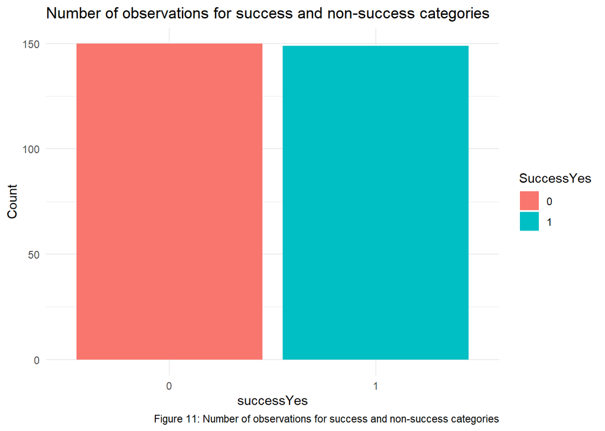

```r
#histogram of successYes variable
ggplot(young_df, aes(x = as.factor(successYes), fill = as.factor(successYes))) +
  geom_bar() +
  labs(title = "Number of observations for success and non-success categories",
       x = "successYes",
       y = "Count",
       caption = 'Figure 11: Number of observations for success and non-success categories',
       fill = 'SuccessYes') +
  theme_minimal()
```

According to Figure 11, this dataset does not exhibit class bias as the number of observations for successful and unsuccessful players is almost the same.

```r
#Split data into train and test sets
#Train 70%
#Test  30%

set.seed(5)
trainIndex <- createDataPartition(young_df$successYes, p = 0.70, list = FALSE, times = 1)

#don't forget ,
train <- young_df[trainIndex,]
test <- young_df[-trainIndex,]
```

Creating a training and testing dataset with a ratio of 70:30 will be employed to train and test the model, ensuring alignment with the training dataset. Additionally, the test dataset will be utilized to assess whether the model is overfitting or not.

```r
#Create model
#successYes cannot be a factor
model <- glm(successYes ~., data = train, family = binomial(link = 'logit'))
summary(model)
```

```
##
## Call:
## glm(formula = successYes ~ ., family = binomial(link = "logit"),
##     data = train)
##
## Coefficients: (2 not defined because of singularities)
##                   Estimate  Std. Error z value Pr(>|z|)
## (Intercept)        -98.381  542520.763   0.000    1.000
## years               -1.105   42520.288   0.000    1.000
## home               -15.914   47608.304   0.000    1.000
## win                  3.718   82954.712   0.000    1.000
## gs                  -6.720   81941.103   0.000    1.000
## mp                  -1.388    5707.063   0.000    1.000
## fg                  -5.182   78336.219   0.000    1.000
## fga                  9.561   48899.701   0.000    1.000
## fg_pct             190.025 1017588.304   0.000    1.000
## x3p                 45.198  146748.618   0.000    1.000
## x3pa               -40.921   47966.060  -0.001    0.999
## x3p_pct            -60.587  266947.828   0.000    1.000
## ft                   5.093   34699.568   0.000    1.000
## fta                  2.376   32054.474   0.000    1.000
## ft_pct             -12.206  123201.088   0.000    1.000
## orb                -12.317   34228.844   0.000    1.000
## drb                 -9.373   11251.507  -0.001    0.999
## trb                     NA          NA      NA       NA
## ast                 11.761   22515.532   0.001    1.000
## stl                 -6.248   18567.836   0.000    1.000
## blk                  5.984   30804.783   0.000    1.000
## tov                 10.098   28152.246   0.000    1.000
## pf                  11.225   15437.845   0.001    0.999
## pts                     NA          NA      NA       NA
## close_game          -3.057   90433.570   0.000    1.000
## pts_per_minute     -49.971   98687.689  -0.001    1.000
##
## (Dispersion parameter for binomial family taken to be 1)
##
##     Null deviance: 290.950363932514  on 209  degrees of freedom
## Residual deviance:   0.000000024085  on 186  degrees of freedom
## AIC: 48
##
## Number of Fisher Scoring iterations: 25
```

Subset selection

```r
#Backward selection method
final_modelB <- step(model, direction = "backward")
```

```r
final_modelB
```

```
##
## Call:  glm(formula = successYes ~ home + fga + x3pa + ft + orb + drb +
##     ast + pts_per_minute, family = binomial(link = "logit"),
##     data = train)
##
## Coefficients:
##    (Intercept)            home             fga            x3pa              ft
##        -8092.4         -2585.0           749.2         -3714.4          1052.7
##            orb             drb             ast  pts_per_minute
##        -2717.8         -1235.6          2349.8         -2415.2
##
## Degrees of Freedom: 209 Total (i.e. Null);  201 Residual
## Null Deviance:       291
## Residual Deviance: 0.00005024    AIC: 18
```

```r
#Forward selection method
final_modelF <- step(model, direction = "forward")
```

```r
final_modelF
```

```
##
## Call:  glm(formula = successYes ~ years + home + win + gs + mp + fg +
##     fga + fg_pct + x3p + x3pa + x3p_pct + ft + fta + ft_pct +
##     orb + drb + trb + ast + stl + blk + tov + pf + pts + close_game +
##     pts_per_minute, family = binomial(link = "logit"), data = train)
##
## Coefficients:
##    (Intercept)           years            home             win              gs
##        -98.381          -1.105         -15.914           3.718          -6.720
##             mp              fg             fga          fg_pct             x3p
##         -1.388          -5.182           9.561         190.025          45.198
##           x3pa         x3p_pct              ft             fta          ft_pct
##        -40.921         -60.587           5.093           2.376         -12.206
##            orb             drb             trb             ast             stl
##        -12.317          -9.373              NA          11.761          -6.248
##            blk             tov              pf             pts      close_game
##          5.984          10.098          11.225              NA          -3.057
## pts_per_minute
##        -49.971
##
## Degrees of Freedom: 209 Total (i.e. Null);  186 Residual
## Null Deviance:       291
## Residual Deviance: 0.00000002409     AIC: 48
```

```r
#Step wise
final_modelS <- step(model, direction = "both")
```

```r
final_modelS
```

```
##
## Call:  glm(formula = successYes ~ home + fga + x3pa + ft + orb + drb +
##     ast + pts_per_minute, family = binomial(link = "logit"),
##     data = train)
##
## Coefficients:
##    (Intercept)            home             fga            x3pa              ft
##        -8092.4         -2585.0           749.2         -3714.4          1052.7
##            orb             drb             ast  pts_per_minute
##        -2717.8         -1235.6          2349.8         -2415.2
##
## Degrees of Freedom: 209 Total (i.e. Null);  201 Residual
## Null Deviance:       291
## Residual Deviance: 0.00005024    AIC: 18
```

```r
#Compare AIC
AIC <- c(AIC(final_modelB), AIC(final_modelF), AIC(final_modelS))
model_names <- c("Backward Selection", "Forward Selection", "Stepwise Selection")

best_model_index <- which(AIC == min(AIC))
best_model <- list(final_modelB, final_modelF, final_modelS)[best_model_index]
best_model
```

```
## [[1]]
##
## Call:  glm(formula = successYes ~ home + fga + x3pa + ft + orb + drb +
##     ast + pts_per_minute, family = binomial(link = "logit"),
##     data = train)
##
## Coefficients:
##    (Intercept)            home             fga            x3pa              ft
##        -8092.4         -2585.0           749.2         -3714.4          1052.7
##            orb             drb             ast  pts_per_minute
##        -2717.8         -1235.6          2349.8         -2415.2
##
## Degrees of Freedom: 209 Total (i.e. Null);  201 Residual
## Null Deviance:       291
## Residual Deviance: 0.00005024    AIC: 18
##
## [[2]]
##
## Call:  glm(formula = successYes ~ home + fga + x3pa + ft + orb + drb +
##     ast + pts_per_minute, family = binomial(link = "logit"),
##     data = train)
##
## Coefficients:
##    (Intercept)            home             fga            x3pa              ft
##        -8092.4         -2585.0           749.2         -3714.4          1052.7
##            orb             drb             ast  pts_per_minute
##        -2717.8         -1235.6          2349.8         -2415.2
##
## Degrees of Freedom: 209 Total (i.e. Null);  201 Residual
## Null Deviance:       291
## Residual Deviance: 0.00005024    AIC: 18
```

```r
print(coef(best_model)[1])
```

[output not shown]

```r
if (length(best_model_index) > 1) {
  cat("Best Models:", paste(model_names[best_model_index], collapse = ", "), "\n")
} else {
  cat("Best Model:", model_names[best_model_index], "\n")
}
```

```
## Best Models: Backward Selection, Stepwise Selection
```

#### Model equation

```r
#equation
#(Source: OpenAI, 2024)
coefficients <- round(coef(final_modelS),4)

equation <- paste("log(p / (1 - p)) =",
                   paste(c("Intercept", paste("(", coefficients[-1], "*", names(coefficients[-1]), ")", collapse = " + ")), collapse = " + "),
                   sep = " ")
equation
```

```
## [1] "log(p / (1 - p)) = Intercept + ( -2584.987 * home ) + ( 749.176 * fga ) + ( -3714.4082 * x3pa ) + ( 1052.7036 * ft ) + ( -2717.7522 * orb ) + ( -1235.6234 * drb ) + ( 2349.8478 * ast ) + ( -2415.2236 * pts_per_minute )"
```

Create a confusion matrix

```r
#Train set prediction
set.seed(5)

#type = response => for
probabilities.train <- predict(final_modelS, newdata = train, type = 'response')

#optimal cutoff
optCutOff <- optCutoff(probabilities.train, train$win,  namePos = 1) [1]
cat("Optimal cutoff (threshold) is = ", optCutOff, "\n")
```

```
## Optimal cutoff (threshold) is =  1
```

```r
predicted.classes.min <- as.factor(ifelse(probabilities.train >= optCutOff, '1', '0'))

train$successYes <- factor(train$successYes, levels = levels(predicted.classes.min))

#Model accuracy
conf_matrix <- confusionMatrix(predicted.classes.min, train$successYes, positive = '1')
conf_matrix
```

```
## Confusion Matrix and Statistics
##
##           Reference
## Prediction   0   1
##          0 108   4
##          1   0  98
##
##                Accuracy : 0.981
##                  95% CI : (0.952, 0.9948)
##     No Information Rate : 0.5143
##     P-Value [Acc > NIR] : <0.0000000000000002
##
##                   Kappa : 0.9618
##
##  Mcnemar's Test P-Value : 0.1336
##
##             Sensitivity : 0.9608
##             Specificity : 1.0000
##          Pos Pred Value : 1.0000
##          Neg Pred Value : 0.9643
##              Prevalence : 0.4857
##          Detection Rate : 0.4667
##    Detection Prevalence : 0.4667
##       Balanced Accuracy : 0.9804
##
##        'Positive' Class : 1
##
```

In the confusion matrix of the training set, the model accurately predicts ‘No’ (not success) 108 times and ‘Yes’ (success) 98 times. However, it also makes errors, specifically in the case of False Negatives (Type II Error). These occur when the actual status is ‘Yes’ (Success), but the model predicts ‘No’, happening around 4 times.

```r
#Test set predictions
probabilities.test <- predict(final_modelS, newdata = test, type = 'response')
predicted.classes.min <- as.factor(ifelse(probabilities.test >= optCutOff, '1', '0'))

test$successYes <- factor(test$successYes, levels = levels(predicted.classes.min))

#Model accuracy
conf_matrix_test <- confusionMatrix(predicted.classes.min, test$successYes, positive = '1')
conf_matrix_test
```

```
## Confusion Matrix and Statistics
##
##           Reference
## Prediction  0  1
##          0 40  4
##          1  2 43
##
##                Accuracy : 0.9326
##                  95% CI : (0.859, 0.9749)
##     No Information Rate : 0.5281
##     P-Value [Acc > NIR] : <0.0000000000000002
##
##                   Kappa : 0.8651
##
##  Mcnemar's Test P-Value : 0.6831
##
##             Sensitivity : 0.9149
##             Specificity : 0.9524
##          Pos Pred Value : 0.9556
##          Neg Pred Value : 0.9091
##              Prevalence : 0.5281
##          Detection Rate : 0.4831
##    Detection Prevalence : 0.5056
##       Balanced Accuracy : 0.9336
##
##        'Positive' Class : 1
##
```

In the confusion matrix of the test set, the model accurately predicts ‘No’ (not success) 40 times and ‘Yes’ (success) 43 times. However, it makes errors in both categories: False Positives (Type I error) and False Negatives (Type II Error). False Positives occur when the actual status is ‘No’ (not success), but the model predicts ‘Yes’, happening around 2 times. False Negatives occur when the actual status is ‘Yes’ (Success), but the model predicts ‘No’, happening around 4 times. The model makes slightly more incorrect predictions on the test set compared to the training set.

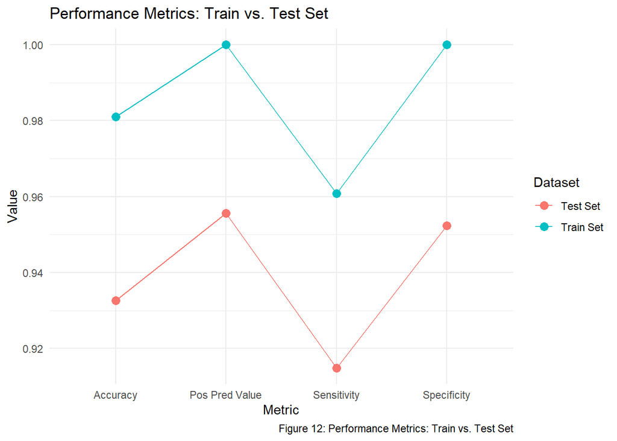

```r
#Create a dataframe
performance_df <- data.frame(
  Metric = c("Accuracy",
            "Pos Pred Value",
            "Sensitivity",
            "Specificity",
            "Accuracy",
            "Pos Pred Value",
            "Sensitivity",
            "Specificity"),
  Value = c(round(conf_matrix$overall['Accuracy'],4),
           round(conf_matrix$byClass['Pos Pred Value'],4),
           round(conf_matrix$byClass['Sensitivity'],4),
           round(conf_matrix$byClass['Specificity'],4),
           round(conf_matrix_test$overall['Accuracy'],4),
           round(conf_matrix_test$byClass['Pos Pred Value'],4),
           round(conf_matrix_test$byClass['Sensitivity'],4),
           round(conf_matrix_test$byClass['Specificity'],4)),
  Dataset = c('Train Set',
            'Train Set',
            'Train Set',
            'Train Set',
            'Test Set',
            'Test Set',
            'Test Set',
            'Test Set')
)

#Source(Shapiro and Sanchi, 2024)
# Create the line plot
theGraph <- performance_df %>%
  ggplot(aes(x = Metric,
             y = Value,
             group = Dataset,
             color = Dataset)) +
  geom_line() +
  geom_point(size = 3) +
  theme_minimal() +
  labs(title = "Performance Metrics: Train vs. Test Set",
       x = "Metric",
       y = "Value",
       caption = "Figure 12: Performance Metrics: Train vs. Test Set",)

theGraph
```

From performance metrics on Figure 12, overall performance on test set is lower than train set which is normal expectation but there is no significant different from 2 train and test set and no significant overfitting on train set.

Plot and interpret the ROC curve.

```r
ROC1 <- roc(test$successYes, probabilities.test)
```

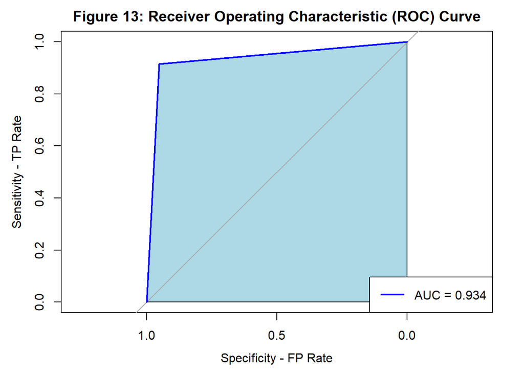

```r
auc <- round(auc(ROC1),3)

#Source(Sharanya and Sharanya, 2024)
plot(ROC1, col = 'blue',
     ylab= 'Sensitivity - TP Rate',
     xlab = 'Specificity - FP Rate',
     main = 'Figure 13: Receiver Operating Characteristic (ROC) Curve',
     auc.polygon.col = "lightblue",
     auc.polygon = TRUE)
legend("bottomright", legend = paste("AUC =", auc), col = "blue", lwd = 2)
```

In Figure 13, the AUC (area under the ROC curve) is a measure of the model’s discrimination, with a value close to 1 indicating perfect discrimination In this case, the AUC is notably high at 0.934, suggesting a well-discriminating model.

BQ4 Recommendation:

Scouts use the model to discover new, talented basketball players and negotiate contracts at lower prices.

### BQ 5: Predict: The binary outcome variable ‘win’ (0 or1)

**Based on:** Michael Jordan’s statistics playing with Chicago Bulls, while excluding irrelevant variables such as end_year, tm, date, and gm_sc.

**Using:** Logistic Regression.

```r
#Check Class bias
table(Michael_CHI_df$win)
```

```
##
##   0   1
## 291 639
```

```r
success_distribution <- round(prop.table(table(Michael_CHI_df$win)) * 100, 2)
success_distribution
```

```
##
##     0     1
## 31.29 68.71
```

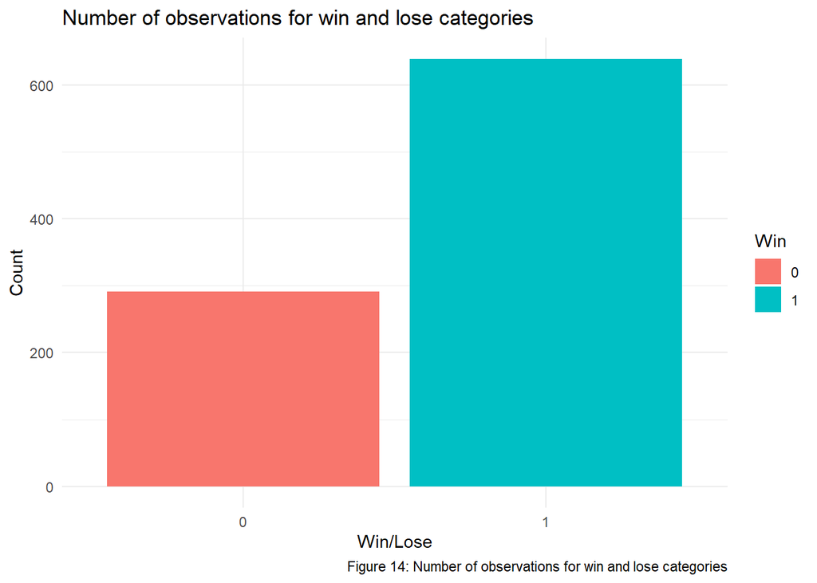

```r
#histogram of successYes variable
ggplot(Michael_CHI_df, aes(x = as.factor(win), fill = as.factor(win))) +
  geom_bar() +
  labs(title = "Number of observations for win and lose categories",
       x = "Win/Lose",
       y = "Count",
       caption = 'Figure 14: Number of observations for win and lose categories',
       fill = 'Win') +
  theme_minimal()
```

```r
#Increase the numbers of the minority class ('No')
#(Source: Klopper, 2019)
unbiased_df <- ovun.sample(win ~ .,
                             data = Michael_CHI_df,
                             method = "over",
                             seed = 123)$data

table(unbiased_df$win)
```

```
##
##   0   1
## 631 639
```

```r
#Split data into train and test sets
#Train 70%
#Test  30%

set.seed(5)
trainIndex <- createDataPartition(unbiased_df$win, p = 0.70, list = FALSE, times = 1)

#don't forget ,
train <- unbiased_df[trainIndex,]
test <- unbiased_df[-trainIndex,]
```

```r
model <- glm(win ~., data = train, family = binomial(link = 'logit'))
summary(model)
```

```
##
## Call:
## glm(formula = win ~ ., family = binomial(link = "logit"), data = train)
##
## Coefficients: (2 not defined because of singularities)
##                  Estimate Std. Error z value            Pr(>|z|)
## (Intercept)     -9.417353   3.356741  -2.806             0.00502 **
## years            0.228226   0.029269   7.797 0.00000000000000632 ***
## home             1.138027   0.184379   6.172 0.00000000067345779 ***
## oppBOS          -0.939412   0.518608  -1.811             0.07008 .
## oppCHH           1.229987   0.676380   1.818             0.06899 .
## oppCLE           0.063319   0.454864   0.139             0.88929
## oppDAL           1.091763   0.738277   1.479             0.13919
## oppDEN           0.113357   0.679053   0.167             0.86742
## oppDET           0.016472   0.456942   0.036             0.97124
## oppGSW           0.173585   0.674758   0.257             0.79698
## oppHOU          -1.189451   0.633875  -1.876             0.06059 .
## oppIND          -0.081072   0.456158  -0.178             0.85894
## oppKCK          17.400409 815.969694   0.021             0.98299
## oppLAC           2.282914   0.936901   2.437             0.01482 *
## oppLAL          -0.441478   0.573074  -0.770             0.44108
## oppMIA           0.061094   0.567213   0.108             0.91423
## oppMIL           0.740799   0.497039   1.490             0.13611
## oppMIN           1.826892   1.191003   1.534             0.12505
## oppNJN           0.035416   0.481870   0.073             0.94141
## oppNYK           0.640687   0.460023   1.393             0.16370
## oppORL          -0.430368   0.570549  -0.754             0.45067
## oppPHI          -0.271820   0.494456  -0.550             0.58250
## oppPHO          -0.112279   0.666242  -0.169             0.86617
## oppPOR          -0.092327   0.663029  -0.139             0.88925
## oppSAC           0.835840   0.731451   1.143             0.25316
## oppSAS           0.358595   0.638410   0.562             0.57432
## oppSEA           1.183411   0.671004   1.764             0.07779 .
## oppTOR          -0.446949   0.749758  -0.596             0.55109
## oppUTA          -0.004256   0.604950  -0.007             0.99439
## oppVAN          14.072296 537.626989   0.026             0.97912
## oppWAS          -0.560808   1.082827  -0.518             0.60452
## oppWSB           1.218832   0.539477   2.259             0.02387 *
## gs               1.753628   0.879082   1.995             0.04606 *
## mp              -0.023035   0.074511  -0.309             0.75721
```

[output cut: 15 more lines]

```
## tov             -0.098674   0.055043  -1.793             0.07303 .
## pf              -0.164803   0.070180  -2.348             0.01886 *
## pts                    NA         NA      NA                  NA
## close_game      -0.614696   0.190191  -3.232             0.00123 **
## pts_per_minute   0.942805   3.466856   0.272             0.78566
## ---
## Signif. codes:  0 '***' 0.001 '**' 0.01 '*' 0.05 '.' 0.1 ' ' 1
##
## (Dispersion parameter for binomial family taken to be 1)
##
##     Null deviance: 1232.16  on 888  degrees of freedom
## Residual deviance:  860.56  on 837  degrees of freedom
## AIC: 964.56
##
## Number of Fisher Scoring iterations: 14
```

```r
##Step wise selection method
final_modelS <- step(model, direction = "both")
```

```r
final_modelS
```

```
##
## Call:  glm(formula = win ~ years + home + opp + gs + mp + fga + fg_pct +
##     x3p + x3pa + x3p_pct + ft + fta + ast + blk + tov + pf +
##     close_game, family = binomial(link = "logit"), data = train)
##
## Coefficients:
## (Intercept)        years         home       oppBOS       oppCHH       oppCLE
##    -8.61386      0.23218      1.15807     -0.89279      1.15006      0.02108
##      oppDAL       oppDEN       oppDET       oppGSW       oppHOU       oppIND
##     1.05432      0.10297     -0.02306      0.15746     -1.18418     -0.08913
##      oppKCK       oppLAC       oppLAL       oppMIA       oppMIL       oppMIN
##    17.35795      2.31606     -0.49613      0.03307      0.74358      1.75565
##      oppNJN       oppNYK       oppORL       oppPHI       oppPHO       oppPOR
##    -0.02684      0.60322     -0.46559     -0.27442     -0.10932     -0.09629
##      oppSAC       oppSAS       oppSEA       oppTOR       oppUTA       oppVAN
##     0.89673      0.43820      1.15983     -0.62740     -0.01978     14.04345
##      oppWAS       oppWSB           gs           mp          fga       fg_pct
##    -0.55825      1.19201      1.69461     -0.04262     -0.03277      5.13004
##         x3p         x3pa      x3p_pct           ft          fta          ast
##     0.80982     -0.36957     -0.89717      0.18819     -0.10570      0.08424
##         blk          tov           pf   close_game
##     0.22997     -0.08738     -0.16111     -0.61178
##
## Degrees of Freedom: 888 Total (i.e. Null);  843 Residual
## Null Deviance:       1232
## Residual Deviance: 863.5     AIC: 955.5
```

#### Model equation

```r
#equation
#(Source: OpenAI, 2024)
coefficients <- round(coef(final_modelS),4)

equation <- paste("log(p / (1 - p)) =",
                   paste(c("Intercept", paste("(", coefficients[-1], "*", names(coefficients[-1]), ")", collapse = " + ")), collapse = " + "),
                   sep = " ")
equation
```

[output not shown]

Create a confusion matrix

```r
#Train set prediction
set.seed(5)

#type = response => for
probabilities.train <- predict(final_modelS, newdata = train, type = 'response')

#optimal cutoff
optCutOff <- optCutoff(probabilities.train, train$win,  namePos = 1) [1]
cat("Optimal cutoff (threshold) is = ", optCutOff, "\n")
```

```
## Optimal cutoff (threshold) is =  0.4852535
```

```r
predicted.classes.min <- as.factor(ifelse(probabilities.train >= optCutOff, '1', '0'))

train$win <- factor(train$win, levels = levels(predicted.classes.min))

#Model accuracy
conf_matrix <- confusionMatrix(predicted.classes.min, train$win, positive = '1')
conf_matrix
```

```
## Confusion Matrix and Statistics
##
##           Reference
## Prediction   0   1
##          0 360 116
##          1  92 321
##
##                Accuracy : 0.766
##                  95% CI : (0.7368, 0.7935)
##     No Information Rate : 0.5084
##     P-Value [Acc > NIR] : <0.0000000000000002
##
##                   Kappa : 0.5315
##
##  Mcnemar's Test P-Value : 0.1108
##
##             Sensitivity : 0.7346
##             Specificity : 0.7965
##          Pos Pred Value : 0.7772
##          Neg Pred Value : 0.7563
##              Prevalence : 0.4916
##          Detection Rate : 0.3611
##    Detection Prevalence : 0.4646
##       Balanced Accuracy : 0.7655
##
##        'Positive' Class : 1
##
```

In the confusion matrix of the training set, the model accurately predicts ‘No’ (Lose) 360 times and ‘Yes’ (Win) 321 times. However, it exhibits a moderate error rate in both categories: False Positives (Type I error) and False Negatives (Type II Error), resulting in an accuracy rate on the training set of around 77%, which could determine whether the prediction model is reliable enough or not or needing more player statistics.

Test set

```r
#Test set predictions
probabilities.test <- predict(final_modelS, newdata = test, type = 'response')
predicted.classes.min <- as.factor(ifelse(probabilities.test >= optCutOff, '1', '0'))
probabilities.test
```

[output not shown]

[output cut: 55 more lines]

[output not shown]

```r
test$win <- factor(test$win, levels = levels(predicted.classes.min))

#Model accuracy
conf_matrix_test <- confusionMatrix(predicted.classes.min, test$win, positive = '1')
conf_matrix_test
```

```
## Confusion Matrix and Statistics
##
##           Reference
## Prediction   0   1
##          0 129  48
##          1  50 154
##
##                Accuracy : 0.7428
##                  95% CI : (0.6958, 0.7859)
##     No Information Rate : 0.5302
##     P-Value [Acc > NIR] : <0.0000000000000002
##
##                   Kappa : 0.4834
##
##  Mcnemar's Test P-Value : 0.9195
##
##             Sensitivity : 0.7624
##             Specificity : 0.7207
##          Pos Pred Value : 0.7549
##          Neg Pred Value : 0.7288
##              Prevalence : 0.5302
##          Detection Rate : 0.4042
##    Detection Prevalence : 0.5354
##       Balanced Accuracy : 0.7415
##
##        'Positive' Class : 1
##
```

In the confusion matrix of the test set, the model accurately predicts ‘No’ (not success) 129 times and ‘Yes’ (success) 154 times. However, it remains errors rate in both categories as same as train set: False Positives (Type I error) and False Negatives (Type II Error).

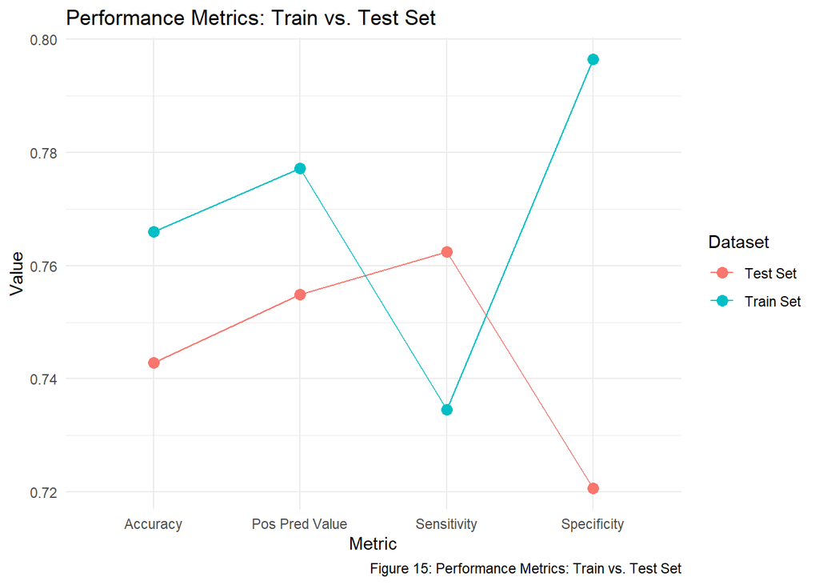

```r
#Create a dataframe
performance_df <- data.frame(
  Metric = c("Accuracy",
            "Pos Pred Value",
            "Sensitivity",
            "Specificity",
            "Accuracy",
            "Pos Pred Value",
            "Sensitivity",
            "Specificity"),
  Value = c(round(conf_matrix$overall['Accuracy'],4),
           round(conf_matrix$byClass['Pos Pred Value'],4),
           round(conf_matrix$byClass['Sensitivity'],4),
           round(conf_matrix$byClass['Specificity'],4),
           round(conf_matrix_test$overall['Accuracy'],4),
           round(conf_matrix_test$byClass['Pos Pred Value'],4),
           round(conf_matrix_test$byClass['Sensitivity'],4),
           round(conf_matrix_test$byClass['Specificity'],4)),
  Dataset = c('Train Set',
            'Train Set',
            'Train Set',
            'Train Set',
            'Test Set',
            'Test Set',
            'Test Set',
            'Test Set')
)

#Source(Shapiro and Sanchi, 2024)
# Create the line plot
theGraph <- performance_df %>%
  ggplot(aes(x = Metric,
             y = Value,
             group = Dataset,
             color = Dataset)) +
  geom_line() +
  geom_point(size = 3) +
  theme_minimal() +
  labs(title = "Performance Metrics: Train vs. Test Set",
       x = "Metric",
       y = "Value",
       caption = "Figure 15: Performance Metrics: Train vs. Test Set",)

theGraph
```

In Figure 15, the accuracy rate on the test set is lower than that on the training set, as expected. The specificity rate, focusing on the accuracy of negative predictions on the training set, is higher than on the test set, albeit with a trade-off resulting in a lower sensitivity rate. Overall, there is no significant difference between the two sets, indicating no significant overfitting on the training set.

Plot and interpret the ROC curve.

```r
ROC1 <- roc(test$win, probabilities.test)
```

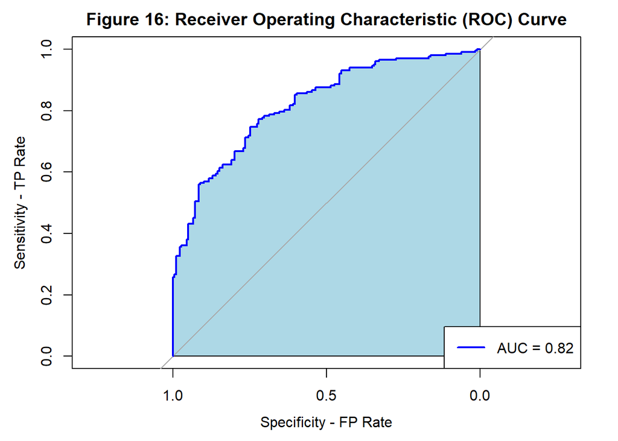

```r
auc <- round(auc(ROC1),3)

#Source(Shapiro and Sharanya, 2024)
plot(ROC1, col = 'blue',
     ylab= 'Sensitivity - TP Rate',
     xlab = 'Specificity - FP Rate',
     main = 'Figure 16: Receiver Operating Characteristic (ROC) Curve',
     auc.polygon.col = "lightblue",
     auc.polygon = TRUE)
legend("bottomright", legend = paste("AUC =", auc), col = "blue", lwd = 2)
```

In Figure 16, the AUC (area under the ROC curve) is a measure of the model’s discrimination, with a value close to 1 indicating perfect discrimination. In this case, the AUC is notably high at 0.82, suggesting a moderately discriminating model.

BQ5 Recommendation:

It is crucial to acknowledge that when making win or lose predictions for future games, if we only use past game statistics to train the model, the model will be based on the next game statistics to predict the next win. This is nonsense and unnecessary because when we get the next game statistics, we already know the result of the game.

Predicting wins or losses should also involve current information before the game start, such as player injuries, team dynamics (including age, the first 5 players, substitute players, and player fit), coaching, and tactic strategy from both internal and opposing teams to improve this model.

In the meantime, our focus on real-time analytics in the current dataset may help with coaching staff can use this prediction model to identify individual impactful factors that influence winning outcomes, thereby increasing the chances of winning future games.

### BQ 6: Predict: The points per minute variable

**Based on:** Michael Jordan’s statistics playing with Chicago Bulls, while excluding irrelevant variables such as end_year, tm, date, and gm_sc.

**Using:** Linear Regression.

Split data into train and test sets

```r
#Split data into train and test sets
#Train 70%
#Test  30%

set.seed(5)
trainIndex <- createDataPartition(Michael_CHI_df$pts_per_minute, p = 0.70, list = FALSE, times = 1)

#don't forget ,
train <- Michael_CHI_df[trainIndex,]
test <- Michael_CHI_df[-trainIndex,]

#cv.glmnet requires matric
train_x <- model.matrix(pts_per_minute ~., train)[,-1]
test_x  <- model.matrix(pts_per_minute ~., test)[,-1]

train_y <- train$pts_per_minute
test_y  <- test$pts_per_minute
```

Estimate the lambda.min and lambda.1se

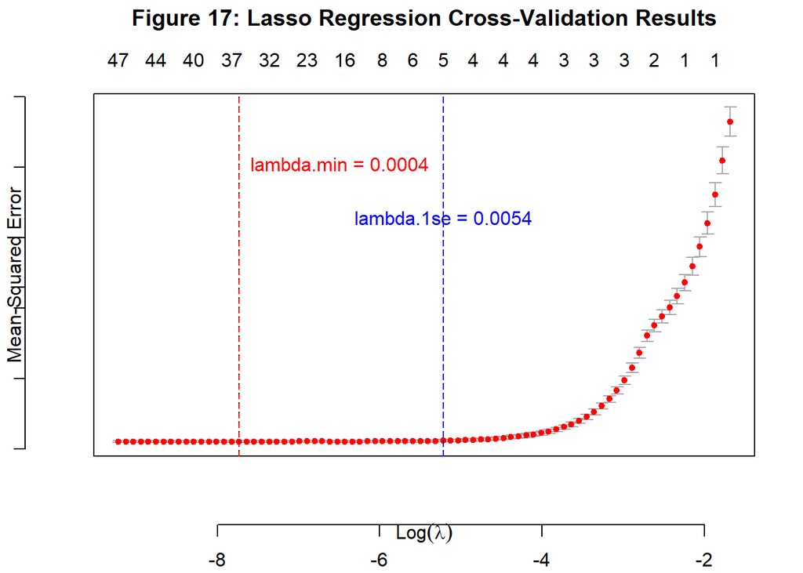

```r
lasso_cv <- cv.glmnet(x = train_x, y = train_y, alpha = 1, nfolds = 10)

lasso_lambda_table <- data.frame(
  Lambda_Type = c("lambda.min", "lambda.1se"),
  Lambda_Value = c(lasso_cv$lambda.min, lasso_cv$lambda.1se)
)

plot(lasso_cv,
     main = "Figure 17: Lasso Regression Cross-Validation Results",
     line = 3)

#Source(Shapiro and Sankalp, Monika, Sanchi, Pei-Yu, Phuong, Pengxiang, Zeyu, 2024)
abline(v = log(lasso_cv$lambda.min), col = "red", lty = 2)
abline(v = log(lasso_cv$lambda.1se), col = "blue", lty = 2)


# Annotations with lambda.min and lambda.1se values
text(x = log(lasso_cv$lambda.min), y = par("usr")[4] * 0.8, labels = paste("lambda.min =", round(lasso_cv$lambda.min, 4)), pos = 4, col = "red")
text(x = log(lasso_cv$lambda.1se), y = par("usr")[4] * 0.7, labels = paste("lambda.1se =", round(lasso_cv$lambda.1se, 4)), pos = 1, col = "blue")
```

In Figure 17, for lambda.min, there are around 40 variables, while the number of variables on lambda.1se decreases to only 5-6.

```r
lasso_model_min <- glmnet(train_x, train_y, alpha = 1, lambda = lasso_cv$lambda.min)
lasso_model_min
```

```
##
## Call:  glmnet(x = train_x, y = train_y, alpha = 1, lambda = lasso_cv$lambda.min)
##
##   Df  %Dev   Lambda
## 1 37 98.23 0.000439
```

```r
lasso_model_1se <- glmnet(train_x, train_y, alpha = 1, lambda = lasso_cv$lambda.1se)
lasso_model_1se
```

```
##
## Call:  glmnet(x = train_x, y = train_y, alpha = 1, lambda = lasso_cv$lambda.1se)
##
##   Df  %Dev   Lambda
## 1  5 97.73 0.005412
```

```r
lasso_coef_table <- data.frame(
  Variable = colnames(train_x),
  Coefficient.min = coef(lasso_model_min)[-1],
  Coefficient.1se = coef(lasso_model_1se)[-1]
)
lasso_coef_table <- lasso_coef_table[order(-lasso_coef_table$Coefficient.1se),]

knitr::kable(lasso_coef_table, caption = "Table 2: Coefficient Values lasso Regression")
```

Table 2: Coefficient Values lasso Regression

|  | Variable | Coefficient.min | Coefficient.1se |
| --- | --- | --- | --- |
| 52 | pts | 0.0221621 | 0.0245381 |
| 37 | fg_pct | 0.1544594 | 0.0160688 |
| 43 | ft_pct | 0.0417028 | 0.0069628 |
| 1 | years | 0.0001370 | 0.0000000 |
| 2 | home | -0.0022127 | 0.0000000 |
| 3 | oppBOS | 0.0025315 | 0.0000000 |
| 4 | oppCHH | 0.0051968 | 0.0000000 |
| 5 | oppCLE | -0.0009737 | 0.0000000 |
| 6 | oppDAL | 0.0000000 | 0.0000000 |
| 7 | oppDEN | -0.0021185 | 0.0000000 |
| 8 | oppDET | 0.0089512 | 0.0000000 |
| 9 | oppGSW | 0.0000000 | 0.0000000 |
| 10 | oppHOU | 0.0040088 | 0.0000000 |
| 11 | oppIND | 0.0045874 | 0.0000000 |
| 12 | oppKCK | 0.0000000 | 0.0000000 |
| 13 | oppLAC | 0.0000000 | 0.0000000 |
| 14 | oppLAL | -0.0011331 | 0.0000000 |
| 15 | oppMIA | 0.0001420 | 0.0000000 |
| 16 | oppMIL | 0.0000000 | 0.0000000 |
| 17 | oppMIN | 0.0000000 | 0.0000000 |
| 18 | oppNJN | 0.0069153 | 0.0000000 |
| 19 | oppNYK | -0.0061439 | 0.0000000 |
| 20 | oppORL | -0.0118285 | 0.0000000 |
| 21 | oppPHI | 0.0011024 | 0.0000000 |
| 22 | oppPHO | 0.0025821 | 0.0000000 |
| 23 | oppPOR | -0.0000252 | 0.0000000 |
| 24 | oppSAC | 0.0042820 | 0.0000000 |
| 25 | oppSAS | -0.0046496 | 0.0000000 |
| 26 | oppSEA | 0.0048494 | 0.0000000 |
| 27 | oppTOR | -0.0157549 | 0.0000000 |
| 28 | oppUTA | 0.0011540 | 0.0000000 |
| 29 | oppVAN | -0.0156606 | 0.0000000 |
| 30 | oppWAS | 0.0000000 | 0.0000000 |
| 31 | oppWSB | 0.0075033 | 0.0000000 |
| 32 | win | 0.0031879 | 0.0000000 |
| 35 | fg | 0.0000000 | 0.0000000 |
| 36 | fga | 0.0033934 | 0.0000000 |
| 38 | x3p | 0.0074153 | 0.0000000 |
| 39 | x3pa | -0.0010438 | 0.0000000 |
| 40 | x3p_pct | 0.0000000 | 0.0000000 |
| 41 | ft | 0.0000000 | 0.0000000 |
| 42 | fta | 0.0024139 | 0.0000000 |
| 44 | orb | 0.0000000 | 0.0000000 |
| 45 | drb | 0.0001317 | 0.0000000 |
| 46 | trb | 0.0000000 | 0.0000000 |
| 47 | ast | 0.0000000 | 0.0000000 |
| 48 | stl | 0.0014691 | 0.0000000 |
| 49 | blk | 0.0000000 | 0.0000000 |
| 50 | tov | 0.0000000 | 0.0000000 |
| 51 | pf | -0.0009871 | 0.0000000 |
| 53 | close_game | 0.0000000 | 0.0000000 |
| 34 | mp | -0.0208700 | -0.0195614 |
| 33 | gs | -0.1773310 | -0.1201632 |

In Table 2, many coefficients of variables on Lambda.1se have been reduced to zero.

Determine the performance of the fit model against the training set by calculating the root mean square error (RMSE)

```r
preds_lasso_train_min <- predict(lasso_model_min, newx = train_x)
lasso_train_min_rmse <- rmse(train_y, preds_lasso_train_min)

preds_lasso_train_1se <- predict(lasso_model_1se, newx = train_x)
lasso_train_1se_rmse <- rmse(train_y, preds_lasso_train_1se)
```

Determine the performance of the fit model against the test set by calculating the root mean square error (RMSE)

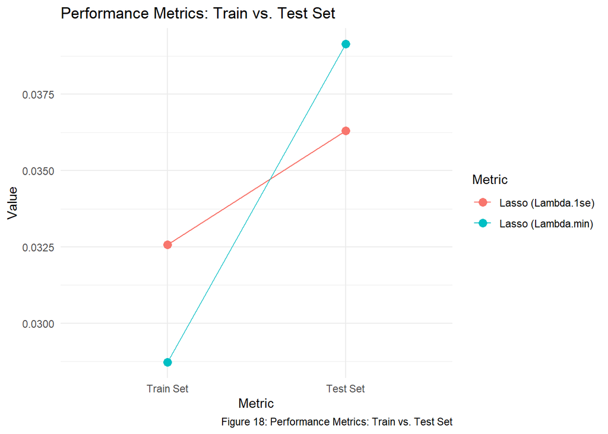

```r
preds_lasso_test_min <- predict(lasso_model_min, newx = test_x)
lasso_test_min_rmse <- rmse(test_y, preds_lasso_test_min)

preds_lasso_test_1se <- predict(lasso_model_1se, newx = test_x)
lasso_test_1se_rmse <- rmse(test_y, preds_lasso_test_1se)

lasso_rmse_table <- data.frame(
  Metric = c("Lasso (Lambda.min)",
            "Lasso (Lambda.min)",
            "Lasso (Lambda.1se)",
            "Lasso (Lambda.1se)"),
  RMSE = c(lasso_train_min_rmse,
           lasso_test_min_rmse,
           lasso_train_1se_rmse,
           lasso_test_1se_rmse),
  Dataset = c('Train Set',
              'Test Set',
              'Train Set',
              'Test Set')
)

# Set the order of levels
lasso_rmse_table <- lasso_rmse_table %>%
  mutate(Dataset = factor(Dataset, levels = c('Train Set', 'Test Set')))

#Source(Shapiro and Sanchi, 2024)
# Create the line plot
theGraph <- lasso_rmse_table %>%
  ggplot(aes(x = Dataset,
             y = RMSE,
             group = Metric,
             color = Metric)) +
  geom_line() +
  geom_point(size = 3) +
  theme_minimal() +
  labs(title = "Performance Metrics: Train vs. Test Set",
       x = "Metric",
       y = "Value",
       caption = "Figure 18: Performance Metrics: Train vs. Test Set")

theGraph
```

From Figure 18, the RSME values for the train set and test set are around 0.03-0.04, indicating that these lasso models can make predictions with new observations and yield similar results as the training set, suggesting that they are not overfitting to the training dataset.

#### Model equation

```r
lasso_coef_1se_table <- data.frame(
  Variable = colnames(train_x),
  Coefficient.1se = coef(lasso_model_1se)[-1]
)

lasso_coef_1se_table <- lasso_coef_1se_table %>%
  filter(Coefficient.1se != 0)

lasso_coef_1se_table$Coefficient.1se <- round(lasso_coef_1se_table$Coefficient.1se, 5)

equation <- paste("Points Per Minute =", paste("(", lasso_coef_1se_table$Coefficient.1se, "*", lasso_coef_1se_table$Variable, ")", collapse = " + "))
equation
```

```
## [1] "Points Per Minute = ( -0.12016 * gs ) + ( -0.01956 * mp ) + ( 0.01607 * fg_pct ) + ( 0.00696 * ft_pct ) + ( 0.02454 * pts )"
```

BQ6 Recommendations:

- The points per minute prediction model reveals the five key factors that impact Jordan’s scoring efficiency in games. Basketball trainers can adjust training schedules based on these impactful factors to enhance player performance and unlock player potential.
- Utilizing points per minute predictions to forecast when a player is likely to score during a basketball match is beneficial. By converting points per minute to the time it takes for a player to score 2 or 3 points, this information helps identify when exciting moments may occur. It can be used to automatically capture video highlights during a game, assisting short video creators in generating content that showcases thrilling shots and can be immediately shared on social platforms.

## **Conclusion**

Through careful analysis of the research questions (BQ1-BQ6) and their corresponding methodologies (M1-M6), we have obtained significant insights into different facets of Michael Jordan’s performance and how it influences team success.

We employed various statistical techniques, including t-tests and ANOVA, to assess the mean points per minute in different situations, identifying significant variations. Chi-square analysis was utilized to examine the independence of winning percentage by year and game score level (two categorical variables). Logistic regression was employed for predicting binary outcomes, specifically to identify the potential next successful player in the future using step-wise subsetting. Finally, Lasso regression was applied to predict points per minute.

Using the successful statistical records of Michael Jordan before his peak performance served as a foundation for creating prediction models to classify who might emerge as the next successful player in the future. Additionally, hypothesis testing played a crucial role in identifying differences in player performance through statistical calculations, ensuring an unbiased assessment.

To summarize, the thorough analyses carried out have provided insights into several aspects of Michael Jordan’s performance and their impact on the success of the team. By comprehending Jordan’s performance across many game scenarios, against diverse adversaries, and in correlation with team achievements, we can extract useful lessons for both individual player advancement and team strategy design. These insights can be utilized to optimize decision-making processes with the goal of increasing player performance and improving team competitiveness on the basketball court.

## **References**

OpenAI. (2022, November 30). *ChatGPT*. Chat.openai.com; OpenAI. https://chat.openai.com

Jabari Parker 2017-18 Game Log. (n.d.). Basketball-Reference.com. Retrieved February 1, 2024, from https://www.basketball-reference.com/players/p/parkeja01/gamelog/2018

Hornets Beware: 7 Biggest busts at pick No. 2 in NBA Draft history. (2023, June 11). Swarm and Sting. https://swarmandsting.com/2023/06/11/hornets-beware-7-biggest-busts-pick-no-2-nba-draft-history/3/